# Intro to NLP coding

Matt Williamson

2023-02-28

# Loading the libraries

One of the benefits of using `R` is the fact that there is an active community of software developers designing functions to complete all kinds of tasks. Once they’ve got a set of functions that go well together, they’ll package them up into a `library` and that library undergoes a bunch of testing to make sure that everything works properly and that there aren’t any risks to users. In order for you to use these packages you first have to call the function that installs them (`install.packages("yourpackagename")`). Once you have the packages installed, you have to load them into your `R` session by calling the `library(yourpackagename)` function (pay attention to the different use of quotes here). We’ll do that first so that we have everything we need for the workflow.

```r
knitr::opts_chunk$set(echo = TRUE)
library(tidyverse) #this is actually a whole set of packages designed to different data manipulation tasks. We rely on the dplyr package alot for organizing data and the stringr package for dealing with text
```

```r
library(httr) # for accessing the html from the link
library(tidytext) # for creating a tidy dataframe from the website text data
library(wordcloud) # package for creating word clouds
#library(reshape2) # package to restructure and aggregate data
library(tm) # package for topic modeling
library(topicmodels)# package for topic modeling
library(SnowballC)
library(googledrive)
options(
  gargle_oauth_cache = ".secrets",
  gargle_oauth_email = TRUE
)
```

# Reading the data

```r
# read in the csv with the urls for the articles
folder_url <- "https://drive.google.com/drive/u/0/folders/1ob5sagTtT3svhc7ZKeemd9TiAq1_MsCL"
folder <- drive_get(as_id(folder_url))
```

```
## ! Using an auto-discovered, cached token.
```

```
##   To suppress this message, modify your code or options to clearly consent to
##   the use of a cached token.
```

```
##   See gargle's "Non-interactive auth" vignette for more details:
```

```
## ℹ The googledrive package is using a cached token for
##   'mattwilliamson@boisestate.edu'.
```

```r
gdrive_files <- drive_ls(folder)
id <- gdrive_files[gdrive_files$name == "Article Coding", ]$id
drive_download(id, path = "data/article_coding.csv", overwrite = TRUE)
```

```
## File downloaded:
```

```
## • 'Article Coding' <id: 1of5iDf_SF7pHCtXuwpQAGnAhEcOENGwIWcaRg38uAUg>
```

```
## Saved locally as:
```

```
## • 'data/article_coding.csv'
```

```r
article_codes <- read.csv(file = 'data/article_coding.csv')
```

# Downloading the articles

In order to do any natural language processing (NLP), we need to get the actual articles and assign them to a data object in our **Environment**. To do that, we need to clean up the data a little. We remove any of the entries that don’t have a link to the article (`filter(!Link=='')` keeps all of the rows where `Link` is not blank). Then we add an `id` column to keep track of which article belongs to each row of our coding dataset (`mutate( id=row_number())` mutates the dataset by creating a new column called `id` and giving it the value that the `row_number()` function returns). Once we have the data cleaned, we need to create a vector of all of the links. We’ll do that and assign it to an object called `urls`.

```r
article_codes <- article_codes %>%
  filter(!Link=='') %>%
  mutate(id = row_number())

# create a vector or list of the urls from the csv
urls <- article_codes$Link
```

## Looping through the links

**Note that you shouldn’t have to change anything here, this section is just to help you know what is happening**

In order to download and store all of the text, we need to create a container to hold them. We do that by creating an empty data frame called `df_article`. We then use a loop (the `for` and `next` parts) to download each article and store it in the `df_article` object. We then change set the column name for the text to `article.text` and create an `id` column.

```r
df_article <- data.frame()

### IMPORTANT!!! Must be connected to VPN or on campus for this to work! ###

for (url in urls){ # this was working, but now I am getting an error: Error in content(page, as = "text"): unused argument ("text")
  if(url == "") next
  link <- url
  #if(link == "") next
  page <- GET(link)
  page_text <- httr::content(page, as = 'text')
  text_body <- str_extract_all(page_text, regex("(?<=<p>).+(?=</p>)"), simplify = TRUE)
  text <- text_body[[2]]
  df_article <- rbind(df_article, text)
}

# Rename and reorder the data frame columns
colnames(df_article) <- c("article.text")
df_article <- df_article %>% mutate(id = row_number()) %>% select(id, article.text)
```

```r
# from the article_codes data frame select one or more variables/columns you would like to join to df_article
# you can update the columns in select() to include whatever information you'd like
# for example, article type, newspaper, etc. But you need the "id" column so that you can "join" the 2 data frames
df_to_join <- article_codes %>% select(id, Species)
df_article <- df_article %>% full_join(df_to_join, by = "id")
```

# Cleaning up the text

Before we can make much sense of the data, we need to clean things up a bit by removing punctuation, making everything lower-case, and getting rid of words that are so common they overwhelm the actual subject of the articles. The `unnest_tokens` function deals with punctuation and capitalization. The `stop words` dataset is a pre-made set of common words that need to be removed from most articles before we can proceed with language processing. We might decide that we need to remove some additional words beyond the typical ones. We do that by creating the `my_stop_words` object. Finally, we use the `anti_join` function to get rid of all of the words in our corpus that match the words in our stop words object. `anti_join` takes all of the pieces of the first object *NOT* in the second object. Finally, we might “stem” words to get rid of differences in prefixes or suffixes. This helps us avoid treating words like bear and bears as different terms. We use the `wordStem` function to accomplish this.

```r
# Make a tidy data frame by "unnesting" the tokens
# This automatically removes punctuation and will lowercase all words
tidy_df <- df_article %>% unnest_tokens(word, article.text)

# Remove "stop words" using the SMART lexicon
data("stop_words")
tidy_df <- tidy_df %>%
  anti_join(stop_words)
# Create a small data frame of your own stop words for this project
# ("br" and "strong" are part of the html formatting which should come out before making tidy df!)
# This needs to be a data frame so that you can use "anti-join()"
# You can add your own words to this list
my_stop_words <- data.frame(c("br", "strong"))
colnames(my_stop_words) <-("word")

tidy_df <- tidy_df %>%
  anti_join(my_stop_words) %>%
  mutate(stem = wordStem(word))
```

## Document Term Matrices

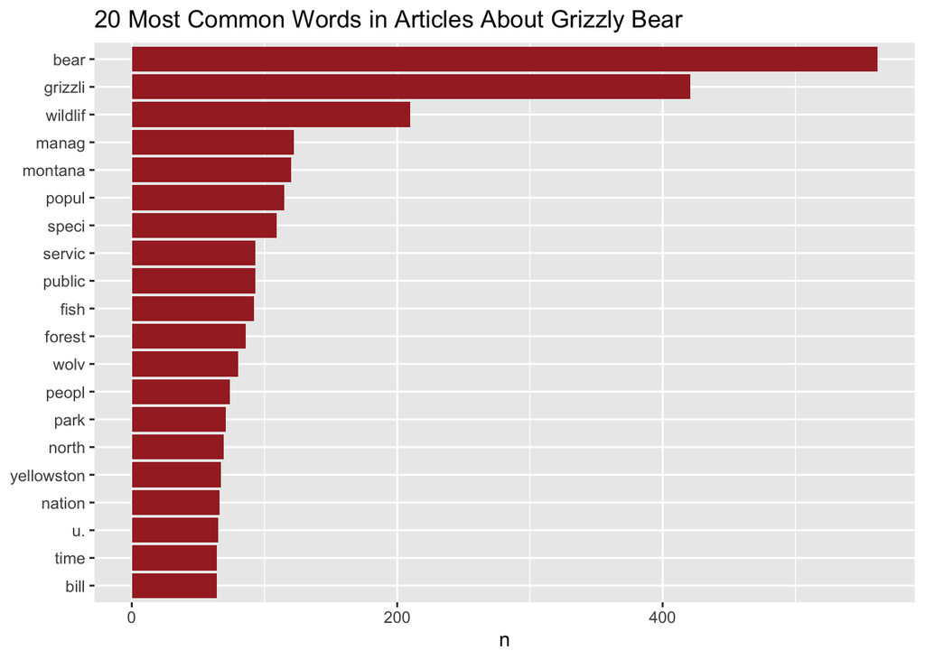

```r
species <- c("Grizzly Bear", "Grizzly bear")
tidy_df_species <- tidy_df %>%
  filter(Species %in% species)

# Create a document term matrix. You will need this for topic modeling
# You will need to create a word count for all of the words in a document
dtm_species <- tidy_df_species %>%
  count(id, word) %>%
  cast_dtm(id, word, n)

tidy_df_species %>%
  count(stem, sort = TRUE) %>%
  slice_max(n, n=20) %>%  # set the number of words to show
  mutate(stem = reorder(stem, n)) %>%
  ggplot(aes(n, stem)) +
  geom_col(fill = "brown") +
  labs(title = paste("20 Most Common Words in Articles About", species), # update the Species
       y = NULL)
```

## Sentiment Analyses

```r
sent_species <- tidy_df_species %>%
  inner_join(get_sentiments("bing")) %>%
  count(word, sentiment, sort = TRUE) %>%
  ungroup()
```

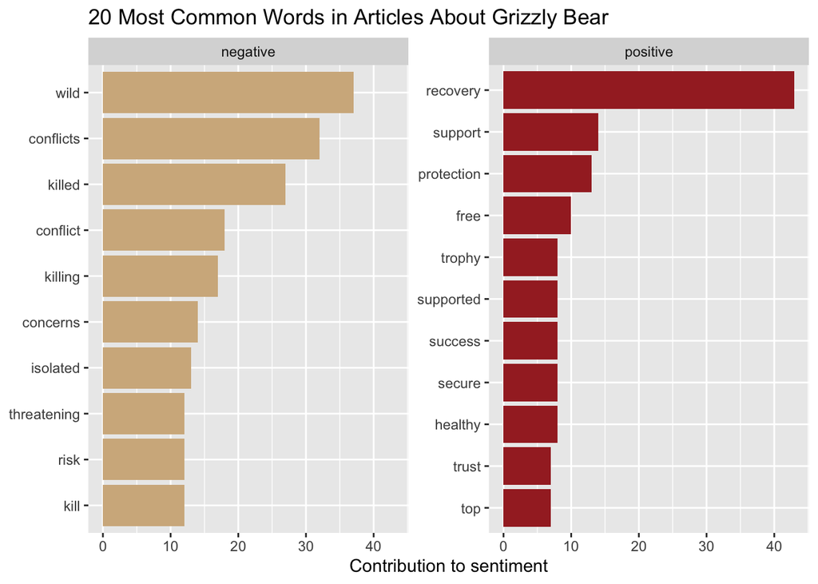

```r
# Use the sentiment word counts data frame to make the plot
sent_species %>%
  group_by(sentiment) %>%
  slice_max(n, n = 10) %>%
  ungroup() %>%
  mutate(word = reorder(word, n)) %>%
  ggplot(aes(n, word, fill = sentiment)) +
  scale_fill_manual(values=c("tan", "brown")) + # change the colors of the bar plot
  geom_col(show.legend = FALSE) +
  facet_wrap(~sentiment, scales = "free_y") +
  labs(x = "Contribution to sentiment",
       y = NULL,
       title = paste("20 Most Common Words in Articles About", species))
```

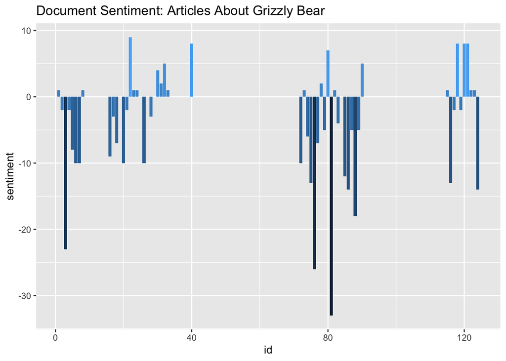

```r
tidy_df_species %>%
  inner_join(get_sentiments("bing")) %>%
  count(id, sentiment) %>%
  pivot_wider(names_from = sentiment, values_from = n, values_fill = 0) %>%
  mutate(sentiment = positive - negative) %>%
  ggplot(aes(id, sentiment, fill = sentiment)) +
  geom_col(show.legend = FALSE) +
  labs(title = paste("Document Sentiment: Articles About", species))
```

## Word Clouds

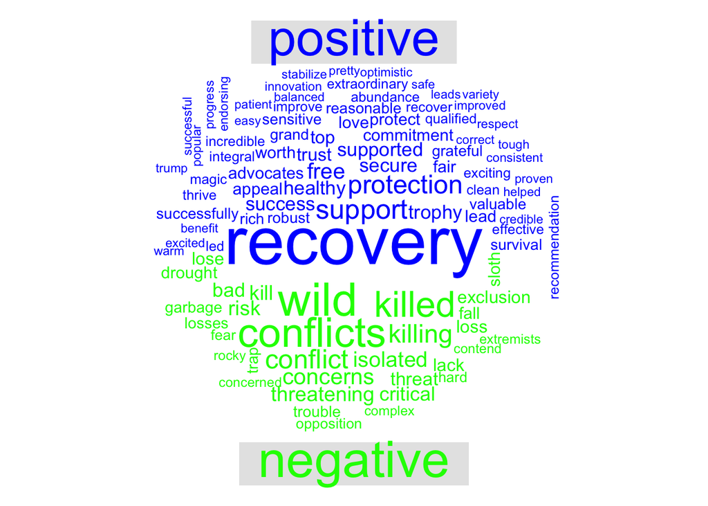

```r
d <- tidy_df_species %>%
  inner_join(get_sentiments("bing")) %>%
  count(word, sentiment, sort = TRUE) %>%
  pivot_wider(id_cols = word, names_from = sentiment, values_from = n, values_fill = 0) %>%
  column_to_rownames(var="word") %>%
  as.matrix() %>%
  comparison.cloud(colors = c("blue", "green"),
                   max.words = 100, match.colors = TRUE)
```